# Sociología del Género

SOL3061 | C5. Sistema multinivel e interseccionalidad

Tania Hutt

## Hoy

1. El género como **estructura social multinivel** (Risman, 2021)
2. Componentes **materiales** y **culturales** en cada nivel
3. La **causalidad recursiva** entre niveles
4. **Interseccionalidad**: orígenes, debates y aplicaciones
5. Ejemplo empírico: Cech (2022) sobre privilegio interseccional en STEM

## El género como estructura social

- El género no es un rasgo de personalidad ni sólo una performance: es una **estructura social** tan sistemática como la estructura económica o política (Risman, 2021).
- Risman propone entenderlo como articulado en **procesos sociales** que operan a nivel **individual**, **interactivo** y **macrosocial**.
- Cada nivel tiene componentes **materiales** (condiciones concretas, distribución de recursos, cuerpos) y **culturales** (significados, creencias, ideologías).
- La relación entre niveles es de **causalidad recursiva**: la estructura moldea la acción, y la acción sostiene o transforma la estructura (Giddens, 1984; Connell, 1987).

## Modelo multinivel de Risman (2021)

|  | **Individual** | **Interactivo** | **Macro** |
| --- | --- | --- | --- |
| **Material** | El cuerpo / trabajo del cuerpo | Representación proporcional, acceso a redes sociales | Distribución de recursos materiales, prácticas organizacionales |
| **Cultural** | Socialización, internalización, trabajo de identidad, construcción de sí | Expectativas de estatus, sesgo cognitivo, los otros / las otras, estereotipos | Ideología, creencias hegemónicas, lógicas institucionales |

## Nivel individual

### Material

- Los **cuerpos** como realidad material: no sólo hombres y mujeres, sino también quienes rechazan las identidades binarias.
- El cuerpo como sitio de inscripción de la estructura de género: el concepto de **habitus** (Bourdieu, 1988).

### Cultural

- **Socialización** y modelamiento: cómo se internalizan preferencias de género desde la primera infancia.
- **Trabajo de identidad**: las personas no son receptoras pasivas; utilizan la identidad para mantener un sentido positivo de sí (Schwalbe et al., 2000).
- La **perdurabilidad** del género a lo largo de la vida: opciones permitidas y limitaciones establecidas.

## Nivel interaccional

### Cultural

- **Expectativas de estatus** vinculadas al género: Ridgeway (2011) muestra que las expectativas de género son *transsituacionales*.
- **“Hacer género”** (*doing gender*): West y Zimmerman (1987) — hacemos género para satisfacer las expectativas de interacción.
- La **rendición de cuentas** (*accountability*): evaluamos nuestro propio comportamiento y el de las demás personas según normas de género (Hollander, 2013).

### Material

- **“Practicar género”** (Martin, 2003): un proceso que involucra tanto a quien actúa como a quien percibe.
- La presencia de **otras personas** en la misma categoría de género cambia la dinámica material de las interacciones.

## Nivel macro

### Material

- **Distribución de recursos**: el acceso desigual a puestos de poder, la segregación ocupacional, las brechas salariales.
- **Reglas y regulaciones** institucionales: leyes, políticas organizacionales, normativas laborales.
- El poder en las organizaciones sigue siendo predominantemente masculino.

### Cultural

- **Ideologías de género**: creencias hegemónicas sobre lo que es “natural” o “apropiado” para cada género.
- **Lógicas institucionales**: las organizaciones incorporan significados de género en la definición de empleos y puestos (Acker, 1990).
- Las lógicas culturales no son fijas ni inmutables: el campo de las ideas es fundamental para la equidad (Risman, 2021).

## Creencias en Chile: WVS 2017-22

[figure not shown]

## Ejercicio: La brecha salarial de género

**¿Cómo se explica la brecha salarial de género desde cada nivel del modelo de Risman?**

| Nivel | ¿Qué mecanismos operan? |
| --- | --- |
| **Individual** |  |
| **Interaccional** |  |
| **Macro** |  |

**Discutan en parejas: ¿cuál nivel les parece más determinante en el contexto chileno actual? ¿Por qué?**

## Ejercicio: Brecha salarial — síntesis

| Nivel | ¿Qué mecanismos operan? |
| --- | --- |
| **Individual** | Socialización en preferencias ocupacionales, habitus de género, identidades profesionales |
| **Interaccional** | Estereotipos en contratación y evaluación, negociación salarial, redes de contacto |
| **Macro** | Segregación ocupacional, políticas de licencia parental, brecha de cuidado |

## De la estructura multinivel a la interseccionalidad

El modelo multinivel nos muestra **cómo** opera la estructura de género.

Pero el género **nunca opera solo**: siempre está articulado con la raza, la clase, la sexualidad, la discapacidad, la nacionalidad…

**La interseccionalidad** nos ofrece las herramientas para analizar esta articulación.

## ¿Qué es la interseccionalidad?

**Definición (Hill Collins & Bilge, 2020)**

“La interseccionalidad investiga cómo las relaciones de poder que se intersectan influyen en las relaciones sociales en sociedades diversas, así como en las experiencias individuales en la vida cotidiana. Como herramienta analítica, la interseccionalidad considera que las categorías de raza, clase, género, sexualidad, clase, nación, capacidad, etnicidad y edad —entre otras— están interrelacionadas y se moldean mutuamente.”

- No es una teoría cerrada: es una **herramienta analítica** y una **praxis crítica**.
- Cuatro dominios de poder interconectados: **estructural**, **cultural**, **disciplinario** e **interpersonal** (Hill Collins & Bilge, 2020).

## Genealogías de la interseccionalidad (Viveros Vigoya, 2016)

- La perspectiva interseccional no nace en la academia: tiene **raíces en los movimientos sociales** de mujeres racializadas desde el siglo XIX.
  - Olympe de Gouges (1791), Sojourner Truth (1851), el Colectivo del Río Combahee (1977).
- **Kimberlé Crenshaw** (1989): acuña el término a partir del caso legal de las trabajadoras negras de General Motors.
- En América Latina: **trayectoria propia** ligada a las experiencias de mujeres indígenas y afrodescendientes (Carneiro, 2005; Curiel, 2007; Lugones, 2005).

## Crenshaw y el origen del concepto

[video not shown]

[Kimberlé Crenshaw: The urgency of intersectionality (TED Talk)](https://www.youtube.com/watch?v=akOe5-UsQ2o)

## Los debates en torno a la interseccionalidad

- **¿Paradigma o herramienta?** Collins (2000) habla de paradigma; Davis (2008) argumenta que su fuerza reside en su vaguedad productiva.
- **¿Identidades o estructuras?** Tensión entre enfoques micro (identidades fluidas) y macro (sistemas de opresión interconectados) (Viveros Vigoya, 2016).
- **¿Intersección o cosubstancialidad?** Kergoat (2009) propone que las relaciones sociales son **cosubstanciales** (no pueden dividirse secuencialmente) y **coextensivas** (se coproducen mutuamente).
- **Riesgo de banalización**: la interseccionalidad puede convertirse en un “mantra multiculturalista” despolitizado (Viveros Vigoya, 2016).

## Carneiro (2005): “Ennegrecer el feminismo”

**Sueli Carneiro**

“Nosotras —las mujeres negras— formamos parte de un contingente de mujeres, probablemente mayoritario, que nunca se reconoció en este mito [de la fragilidad femenina], porque nunca fuimos tratadas como frágiles. Somos parte de un contingente de mujeres que trabajó durante siglos como esclavas.”

- El **mito de la fragilidad femenina** no aplica a todas las mujeres: universalizar la experiencia de la mujer blanca invisibiliza la experiencia de las mujeres negras e indígenas.
- En sociedades multirraciales como las latinoamericanas, el **racismo** es un eje articulador central de las relaciones de género.

## Discusión: “Ennegrecer” el feminismo en Chile

Carneiro (2005) argumenta que en sociedades multirraciales, el **racismo** es un eje articulador central del género.

- ¿En qué medida aplica este argumento al **contexto chileno**?
- ¿Qué otros ejes (**clase, territorio, migración**) podrían cumplir un rol análogo?
- ¿Cómo se articula la pertenencia étnica (mapuche, migrante) con las experiencias de género en Chile?

## Ridgeway y Kricheli-Katz (2013): Creencias culturales interseccionales

- Las creencias de estatus vinculadas al género **interactúan** con las vinculadas a raza, clase y otras categorías.
- Los grupos **interseccionalmente subordinados** (ej. mujeres negras) enfrentan “restricciones” específicas que no son la suma de ser mujer + ser negra.
- Los grupos **interseccionalmente dominantes** (ej. hombres blancos heterosexuales) gozan de “libertades” acumuladas.
- Pero la relación no es simplemente aditiva: las creencias interseccionales producen experiencias **cualitativamente distintas**.
- Conexión con la **prototipicalidad interseccional** (Chavez & Wingfield, 2018; clase 3): el género está racializado y la raza está generizada. Las personas “no prototípicas” —mujeres negras, hombres asiáticos— experimentan “ataduras y libertades” distintas a las que predice cada eje por separado.

## La cosubstancialidad de las relaciones sociales (Viveros Vigoya, 2016)

- **Kergoat (2009)**: las relaciones de género, raza y clase son **cosubstanciales** — no pueden dividirse en ejes separados para efectos analíticos sin distorsionar la realidad.
- Son también **coextensivas**: se coproducen mutuamente.
  - El género crea la clase (ej. segregación ocupacional).
  - Las relaciones raciales refuerzan las de género (ej. feminidades racializadas).
  - Las relaciones de clase dinamizan las de género (ej. jerarquías entre masculinidades).
- **Viveros Vigoya**: en Quibdó y Armenia (Colombia), las masculinidades se construyen en relación con categorías étnico-raciales y de clase, no como expresión de una “masculinidad universal”.

## Discusión: Cosubstancialidad vs. intersección

Viveros Vigoya (2016) presenta la crítica de Kergoat a la metáfora de la “intersección” y propone la “cosubstancialidad”.

- ¿Qué **gana** y qué **pierde** cada concepto?
- ¿Importa la metáfora que usemos, o es una diferencia puramente semántica?
- ¿Cómo afecta la elección conceptual a la **investigación empírica**?

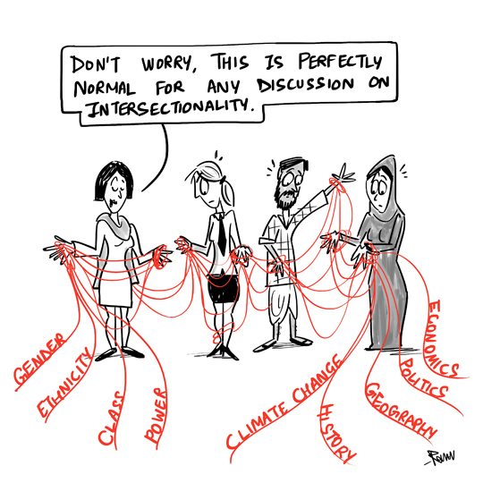

## El riesgo de una interseccionalidad sin poder

- Al convertirse en “la metáfora feminista más difundida”, la interseccionalidad corre el riesgo de perder su filo crítico (Viveros Vigoya, 2016).
- **Wendy Brown (1995)** advierte contra el “mantra multiculturalista”: enumerar categorías (raza, clase, género, sexualidad) sin analizar las **relaciones de poder** que las producen.
- **Hill Collins & Bilge (2020)** insisten: lo que hace interseccional a un análisis no es usar el término ni citar una genealogía estándar, sino investigar cómo **relaciones de poder que se intersectan** moldean un fenómeno concreto.
- Una interseccionalidad despolitizada describe **identidades múltiples** pero no cuestiona las **estructuras de dominación** que las producen.

**Pregunta clave**

¿Mi análisis examina cómo operan relaciones de poder concretas, o sólo describe la “diversidad” de identidades presentes?

## Cech (2022): Acoso por grupo interseccional

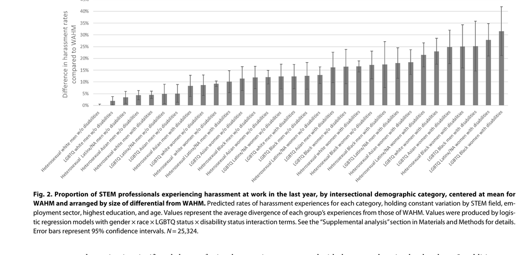

Tasas de acoso por categoría demográfica interseccional, ordenadas por diferencia con WAHM (Cech, 2022, Fig. 2)

## Resultados de Cech (2022): Salario y permanencia

- **Brecha salarial promedio**: $24,994 USD entre WAHM y no-WAHM.
- Después de controlar por capital humano, empleo, esfuerzo y otros factores, **31.3% de la brecha permanece inexplicada**: $7,831 de “premium” por ser WAHM.
- Las brechas son mayores para personas Latinx/NA y personas con discapacidad (≥ $30,000 menos que WAHM).
- **Intenciones de permanencia**: todos los grupos excepto WAHM heterosexuales blancos con discapacidad tienen significativamente menor intención de permanecer en STEM.

## Cech (2022): Descomposición Blinder-Oaxaca

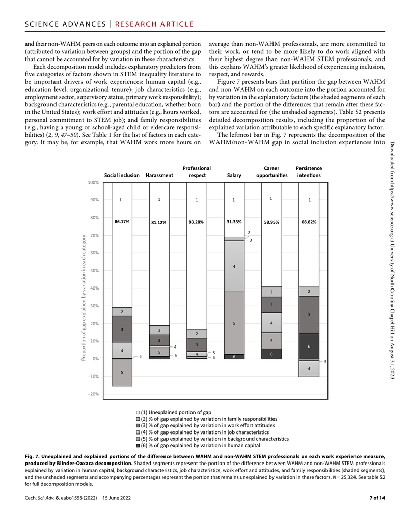

Porción explicada vs. inexplicada de la brecha WAHM/no-WAHM en seis dimensiones

## ¿Qué nos dice Cech sobre la interseccionalidad?

- El privilegio no es simplemente lo opuesto a la desventaja: tiene **mecanismos propios** (homofilia, redes de “old boys”, definiciones de excelencia que reflejan al grupo dominante).
- Los procesos interseccionales **no son consistentemente aditivos**: la marginalización a lo largo del mayor número de ejes no siempre produce la mayor desventaja.
- Las políticas de equidad deben ir más allá de la **representación**: abordar los sistemas culturales, estructurales e institucionales que privilegian a los WAHM.

## Discusión: Privilegio invisible en Chile

Cech (2022) muestra que las ventajas de los WAHM en STEM persisten incluso controlando por factores observables.

- ¿Cómo podríamos estudiar el **privilegio interseccional** en el contexto académico chileno?
- ¿Qué ejes serían más relevantes? (género, clase, universidad de origen, redes)
- ¿Qué datos necesitaríamos para replicar un análisis como el de Cech en Chile?

## Síntesis de la clase

- El género es una **estructura social multinivel** con componentes materiales y culturales en cada nivel, vinculados por causalidad recursiva (Risman, 2021).
- La **interseccionalidad** es una herramienta analítica y política que visibiliza cómo el género se articula con raza, clase, sexualidad, discapacidad (Hill Collins & Bilge, 2020; Viveros Vigoya, 2016).
- Las relaciones sociales son **cosubstanciales y coextensivas**: no pueden analizarse por ejes separados sin distorsionar la realidad (Kergoat/Viveros Vigoya).
- El **privilegio interseccional** opera como premium, no solo como ausencia de desventaja (Cech, 2022).
- El desafío: mantener la **potencia crítica** de la interseccionalidad sin banalizarla ni despolitizarla.

## Referencias

- Acker, J. (1990). Hierarchies, jobs, bodies: A theory of gendered organizations. *Gender & Society*, 4(2), 139–158.
- Bourdieu, P. (1988). *La distinción*. Madrid: Taurus.
- Carneiro, S. (2005). Ennegrecer el feminismo. *Nouvelles Questions Féministes*, 24(2), 21–26.
- Chavez, K. & Wingfield, A. H. (2018). Racializing gendered interactions. En J. W. Messerschmidt et al. (Eds.), *Gender Reckonings* (pp. 185–197). NYU Press.
- Cech, E. A. (2022). The intersectional privilege of white able-bodied heterosexual men in STEM. *Science Advances*, 8, eabo1558.
- Connell, R. W. (1987). *Gender and Power*. Stanford University Press.
- Crenshaw, K. (1989). Demarginalizing the intersection of race and sex. *University of Chicago Legal Forum*, 139.
- Giddens, A. (1984). *The Constitution of Society*. University of California Press.
- Hill Collins, P. & Bilge, S. (2020). *Intersectionality* (2nd ed.). Polity Press.
- Kergoat, D. (2009). Dynamique et consubstantialité des rapports sociaux. En E. Dorlin (Ed.), *Sexe, race, classe, pour une épistémologie de la domination* (pp. 111–126). PUF.
- Ridgeway, C. L. (2011). *Framing Gender*. Oxford University Press.
- Ridgeway, C. L. & Kricheli-Katz, T. (2013). Intersecting cultural beliefs in social relations. *Gender & Society*, 27(3), 294–318.
- Risman, B. J. (2021). *Adónde nos llevará la generación millennial* (cap. 1, pp. 47–69).
- Viveros Vigoya, M. (2016). La interseccionalidad: una aproximación situada a la dominación. *Debate Feminista*, 52, 1–17.